# BankCamp

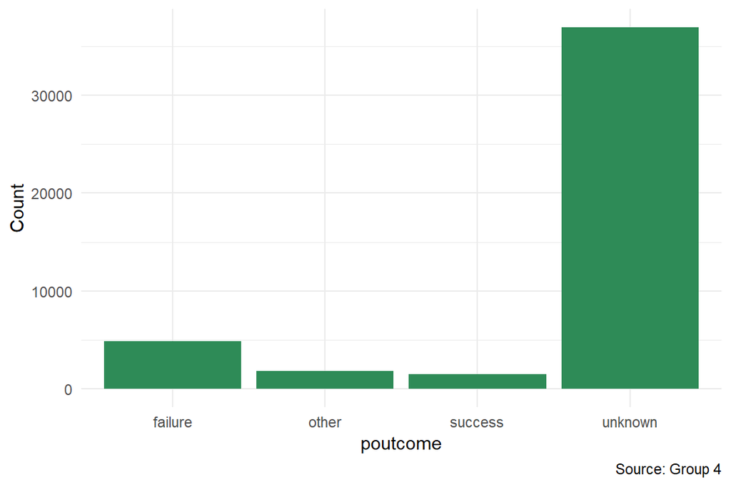

```r
# Count of each category in the whole dataset
ggplot(data = bank_dataset, aes(x = poutcome)) + geom_bar(fill = "seagreen4") + theme_minimal() + labs(x = "poutcome", y = "Count", caption = "Source: Group 4")
```

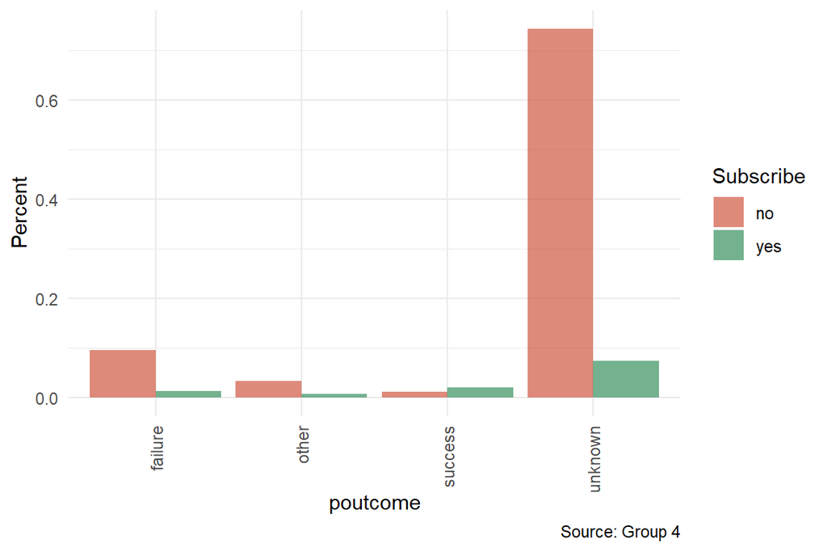

```r
# Probability table
poutcome <- as.data.frame(prop.table(table(bank_dataset[bank_dataset$train_test=="train",]$poutcome, bank_dataset[bank_dataset$train_test=="train",]$y)))
colnames(poutcome) <-  c("poutcome", "y", "perc")

ggplot(data = poutcome, aes(x = poutcome, y = perc, fill = y)) +
  geom_bar(stat = 'identity', position = 'dodge', alpha = 2/3) +xlab("poutcome")+
    ylab("Percent") + theme_minimal() + theme(axis.text.x = element_text(angle = 90, hjust = 1, vjust = 0.5)) +
  scale_fill_manual(values = c("tomato3", "seagreen4")) + labs(fill = "Subscribe", caption = "Source: Group 4")
```

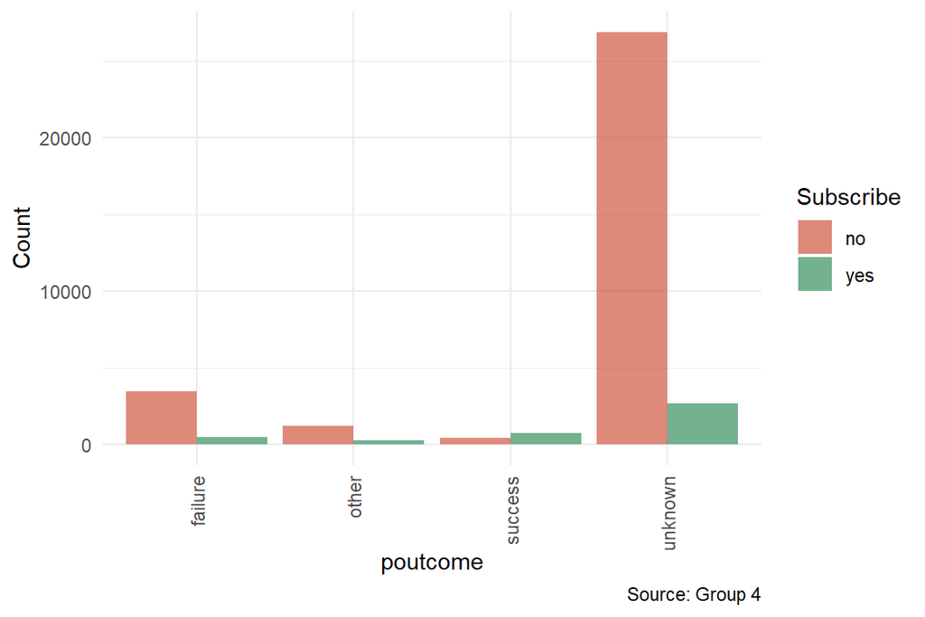

```r
# Using count
poutcome2 <- as.data.frame(table(bank_dataset[bank_dataset$train_test=="train",]$poutcome, bank_dataset[bank_dataset$train_test=="train",]$y))
colnames(poutcome2) <-  c("poutcome", "y", "count")

ggplot(data = poutcome2, aes(x = poutcome, y = count, fill = y)) +
  geom_bar(stat = 'identity', position = 'dodge', alpha = 2/3) +xlab("poutcome")+
    ylab("Count") + theme_minimal() + theme(axis.text.x = element_text(angle = 90, hjust = 1, vjust = 0.5)) +
  scale_fill_manual(values = c("tomato3", "seagreen4")) + labs(fill = "Subscribe", caption = "Source: Group 4")
```

```r
# previous: number of contacts performed before this campaign and for this client (numeric)
table(bank_dataset$previous)
```

```
##
##     0     1     2     3     4     5     6     7     8     9    10    11
## 36954  2772  2106  1142   714   459   277   205   129    92    67    65
##    12    13    14    15    16    17    18    19    20    21    22    23
##    44    38    19    20    13    15     6    11     8     4     6     8
##    24    25    26    27    28    29    30    32    35    37    38    40
##     5     4     2     5     2     4     3     1     1     2     2     1
##    41    51    55    58   275
##     1     1     1     1     1
```

```r
table(bank_dataset[bank_dataset$train_test=="train",]$previous, bank_dataset[bank_dataset$train_test=="train",]$y)
```

```
##
##         no   yes
##   0  26889  2691
##   1   1745   446
##   2   1337   358
##   3    667   235
##   4    444   140
##   5    270   101
##   6    159    66
##   7    121    42
##   8     66    33
##   9     55    20
##   10    32    22
##   11    37    12
##   12    26     8
```

[output cut: 26 more lines]

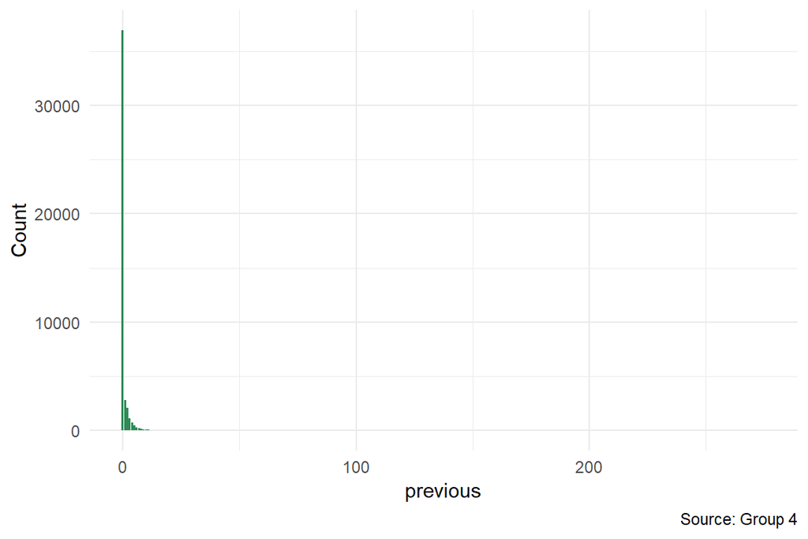

```r
# Count of each category in the whole dataset
ggplot(data = bank_dataset, aes(x = previous)) + geom_bar(fill = "seagreen4") + theme_minimal() + labs(x = "previous", y = "Count", caption = "Source: Group 4")
```

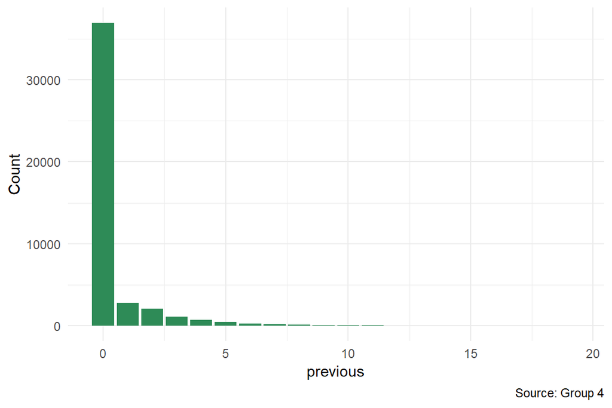

```r
# for a better visualization, we will
ggplot(data = bank_dataset[bank_dataset$previous < 20,], aes(x = previous)) + geom_bar(fill = "seagreen4") + theme_minimal() + labs(x = "previous", y = "Count", caption = "Source: Group 4")
```

```r
min(bank_dataset$balance)
```

```
## [1] -8019
```

```r
max(bank_dataset$balance)
```

```
## [1] 102127
```

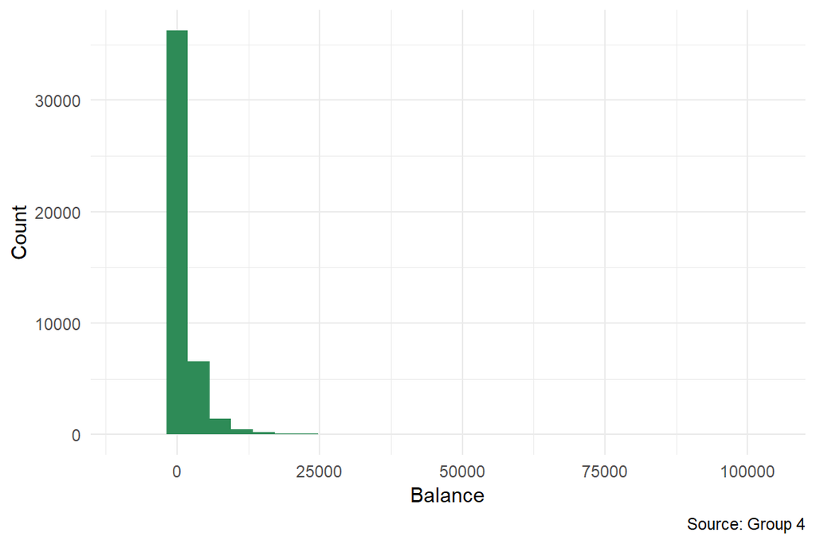

```r
ggplot(bank_dataset, aes(balance)) + geom_histogram(fill = "seagreen4") + theme_minimal() + labs(x = "Balance", y = "Count", caption = "Source: Group 4")
```

```r
bank_dataset <- bank_dataset %>% mutate(balance_range = ifelse(balance < 0, "negative balance",
                                                               ifelse(balance >=0 & balance <= 20000, "low balance",
                                                                      ifelse(balance > 20000 & balance <= 60000, "medium balance",
                                                                             ifelse(balance > 60000, "high balance", NA)))))


table(bank_dataset[bank_dataset$train_test=="train",]$balance_range, bank_dataset[bank_dataset$train_test=="train",]$y)
```

```
##
##                       no   yes
##   high balance         4     1
##   low balance      28962  4002
##   medium balance     125    22
##   negative balance  2882   170
```

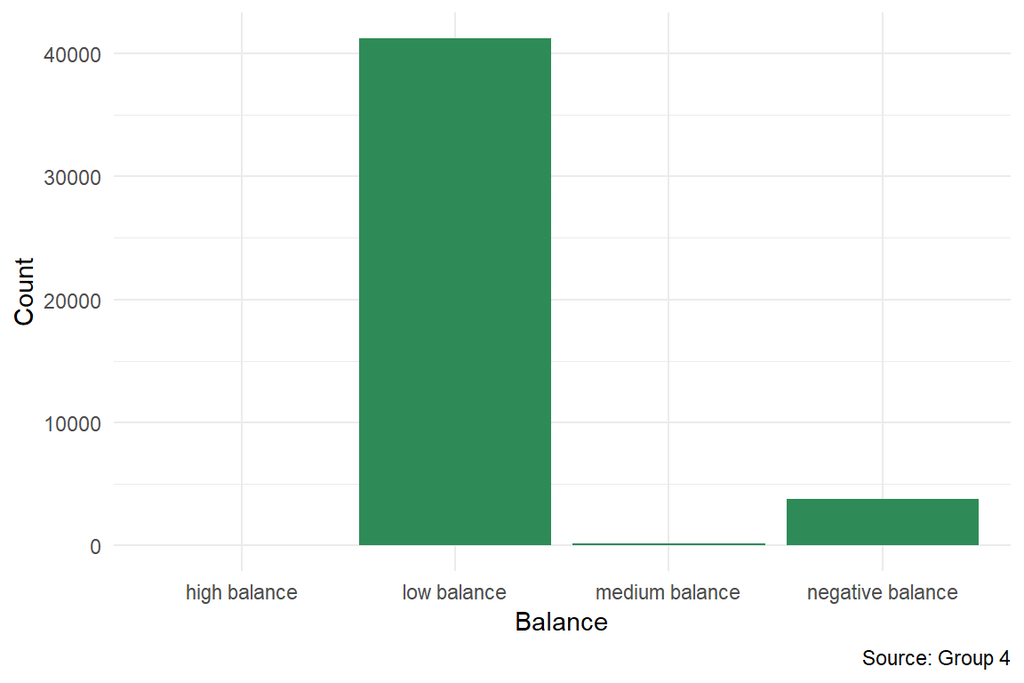

```r
# Count of each category in the whole dataset
ggplot(data = bank_dataset, aes(x = balance_range)) + geom_bar(fill = "seagreen4") + theme_minimal() + labs(x = "Balance", y = "Count", caption = "Source: Group 4")
```

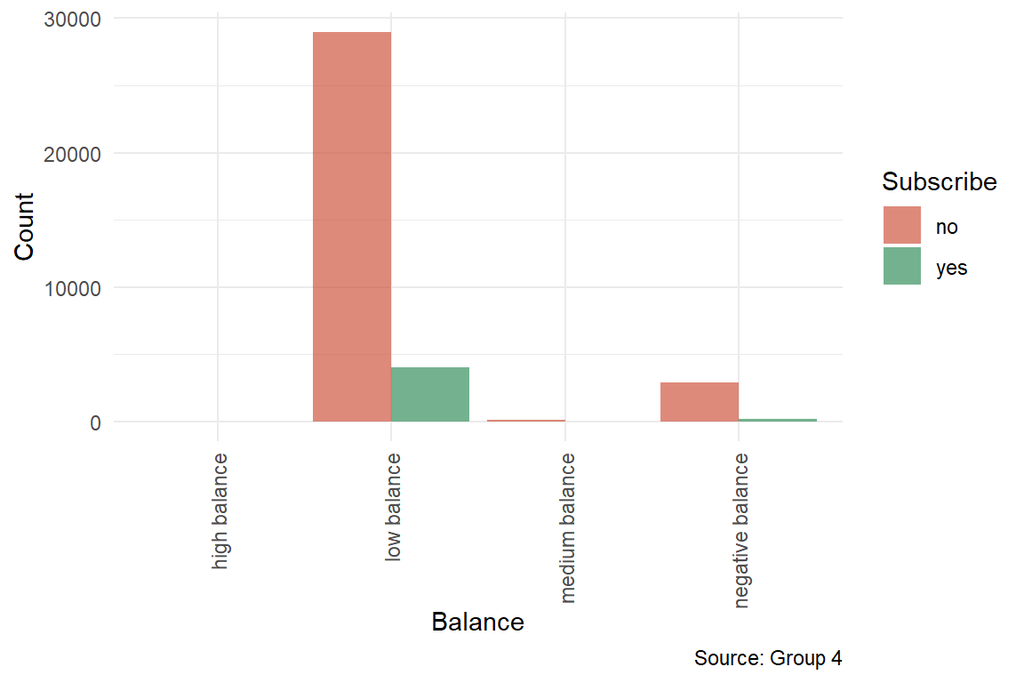

```r
# Using count
balance_group <- as.data.frame(table(bank_dataset[bank_dataset$train_test=="train",]$balance_range,
                                     bank_dataset[bank_dataset$train_test=="train",]$y))
colnames(balance_group) <-  c("balance_range", "y", "count")

ggplot(data = balance_group, aes(x = balance_range, y = count, fill = y)) +
  geom_bar(stat = 'identity', position = 'dodge', alpha = 2/3) +xlab("Balance")+
    ylab("Count") + theme_minimal() + theme(axis.text.x = element_text(angle = 90, hjust = 1, vjust = 0.5)) +
  scale_fill_manual(values = c("tomato3", "seagreen4")) + labs(fill = "Subscribe", caption = "Source: Group 4")
```

```r
table(bank_dataset$month)
```

```
##
##   apr   aug   dec   feb   jan   jul   jun   mar   may   nov   oct   sep
##  2932  6247   214  2649  1403  6895  5341   477 13766  3970   738   579
```

```r
table(bank_dataset[bank_dataset$train_test=="train",]$month, bank_dataset[bank_dataset$train_test=="train",]$y)
```

```
##
##          no   yes
##   apr  1874   461
##   aug  4424   521
##   dec    92    76
##   feb  1748   345
##   jan  1016   113
##   jul  5029   522
##   jun  3844   448
##   mar   178   207
##   may 10333   731
##   nov  2862   313
##   oct   337   258
##   sep   236   200
```

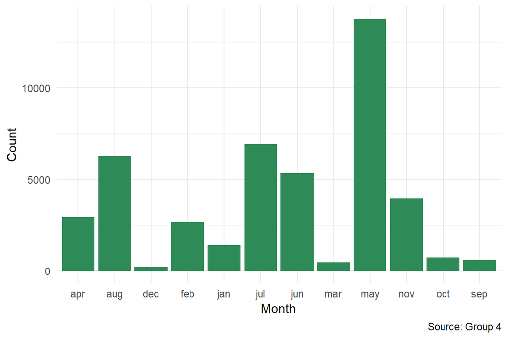

```r
# Count of each category in the whole dataset
ggplot(data = bank_dataset, aes(x = month)) + geom_bar(fill = "seagreen4") + theme_minimal() + labs(x = "Month", y = "Count", caption = "Source: Group 4")
```

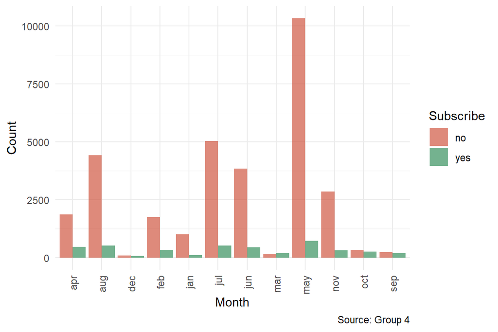

```r
# Using count
month <- as.data.frame(table(bank_dataset[bank_dataset$train_test=="train",]$month,
                                     bank_dataset[bank_dataset$train_test=="train",]$y))
colnames(month) <-  c("month", "y", "count")

ggplot(data = month, aes(x = month, y = count, fill = y)) +
  geom_bar(stat = 'identity', position = 'dodge', alpha = 2/3) +xlab("Month")+
    ylab("Count") + theme_minimal() + theme(axis.text.x = element_text(angle = 90, hjust = 1, vjust = 0.5)) +
  scale_fill_manual(values = c("tomato3", "seagreen4")) + labs(fill = "Subscribe", caption = "Source: Group 4")
```

```r
table(bank_dataset$day)
```

```
##
##    1    2    3    4    5    6    7    8    9   10   11   12   13   14   15
##  322 1293 1079 1445 1910 1932 1817 1842 1561  524 1479 1603 1585 1848 1703
##   16   17   18   19   20   21   22   23   24   25   26   27   28   29   30
## 1415 1939 2308 1757 2752 2026  905  939  447  840 1035 1121 1830 1745 1566
##   31
##  643
```

```r
table(bank_dataset[bank_dataset$train_test=="train",]$day, bank_dataset[bank_dataset$train_test=="train",]$y)
```

```
##
##        no  yes
##   1   176   73
##   2   867  140
##   3   712  140
##   4   987  191
##   5  1344  179
##   6  1414  145
##   7  1311  111
##   8  1330  162
##   9  1118  142
##   10  307   94
##   11 1018  135
##   12 1096  197
##   13 1080  190
```

[output cut: 18 more lines]

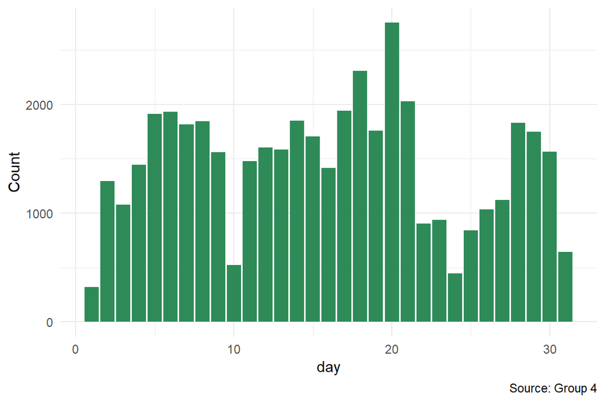

```r
# Count of each category in the whole dataset
ggplot(data = bank_dataset, aes(x = day)) + geom_bar(fill = "seagreen4") + theme_minimal() + labs(x = "day", y = "Count", caption = "Source: Group 4")
```

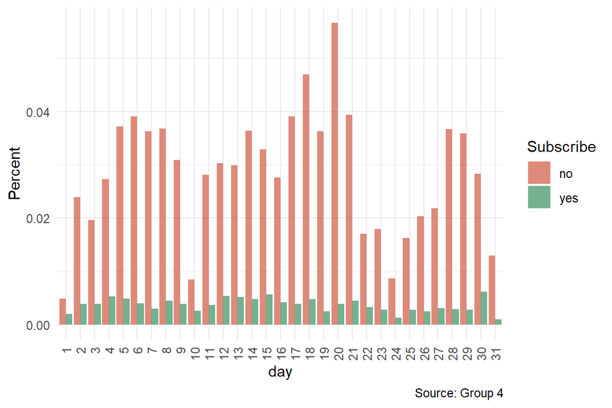

```r
# Probability table
day <- as.data.frame(prop.table(table(bank_dataset[bank_dataset$train_test=="train",]$day, bank_dataset[bank_dataset$train_test=="train",]$y)))
colnames(day) <-  c("day", "y", "perc")

ggplot(data = day, aes(x = day, y = perc, fill = y)) +
  geom_bar(stat = 'identity', position = 'dodge', alpha = 2/3) +xlab("day")+
    ylab("Percent") + theme_minimal() + theme(axis.text.x = element_text(angle = 90, hjust = 1, vjust = 0.5)) +
  scale_fill_manual(values = c("tomato3", "seagreen4")) + labs(fill = "Subscribe", caption = "Source: Group 4")
```

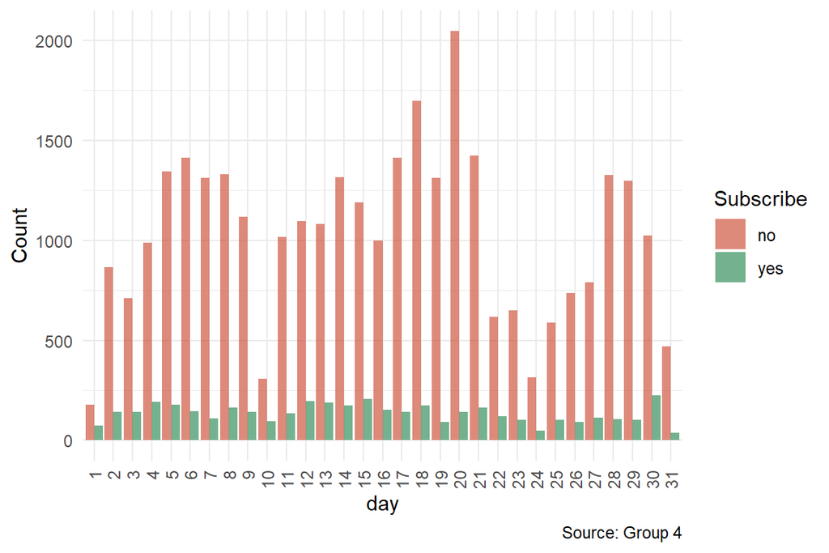

```r
# Using count
day2 <- as.data.frame(table(bank_dataset[bank_dataset$train_test=="train",]$day, bank_dataset[bank_dataset$train_test=="train",]$y))
colnames(day2) <-  c("day", "y", "count")

ggplot(data = day2, aes(x = day, y = count, fill = y)) +
  geom_bar(stat = 'identity', position = 'dodge', alpha = 2/3) +xlab("day")+
    ylab("Count") + theme_minimal() + theme(axis.text.x = element_text(angle = 90, hjust = 1, vjust = 0.5)) +
  scale_fill_manual(values = c("tomato3", "seagreen4")) + labs(fill = "Subscribe", caption = "Source: Group 4")
```

#### Data Cleaning

```r
# for pdays, 999 means that the client was not contacted before so we will replace 999 with zeroes
bank_dataset$pdays[which(bank_dataset$pdays == 999)] <- 0
```

#### Feature Creation/Engineering

```r
bank_dataset[["y"]] <- ifelse(bank_dataset$y == "no", 0, 1)
bank_dataset$y <- as.factor(bank_dataset$y)
```

#### Factorizing Features

```r
bank_dataset$day <- as.factor(bank_dataset$day)
bank_dataset$balance_range <- as.factor(bank_dataset$balance_range)
bank_dataset$duration_group <- as.factor(bank_dataset$duration_group)
bank_dataset$age_group <- as.factor(bank_dataset$age_group)
bank_dataset$campaign_group <- as.factor(bank_dataset$campaign_group)
```

#### Outliers

We will now focus on numerical values. In this section, we will detect numerical features which present outliers and I will clip those values.

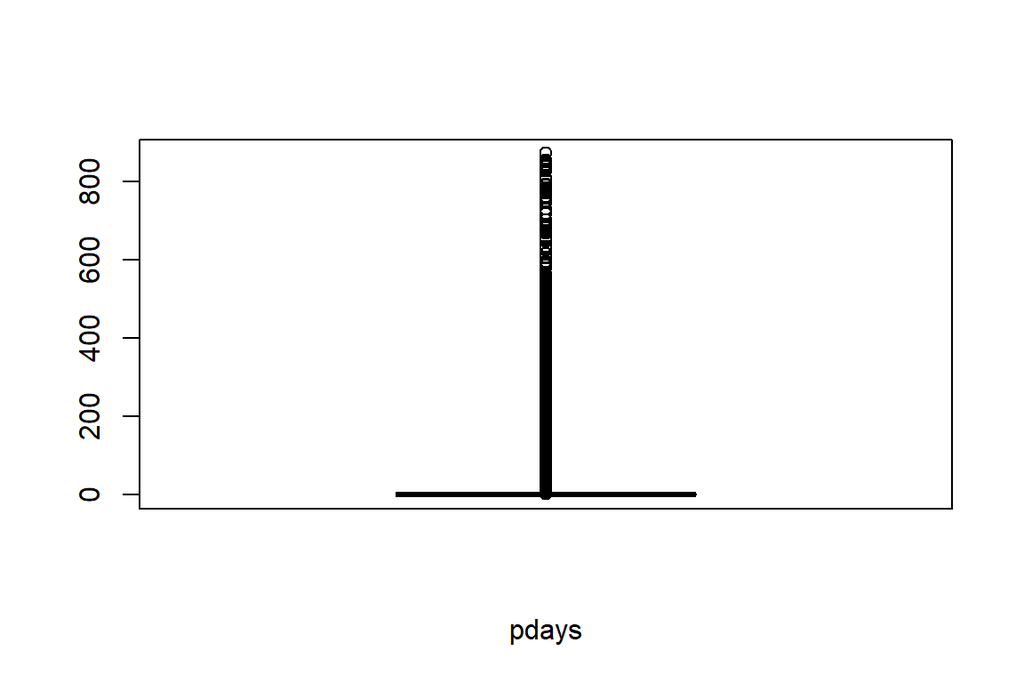

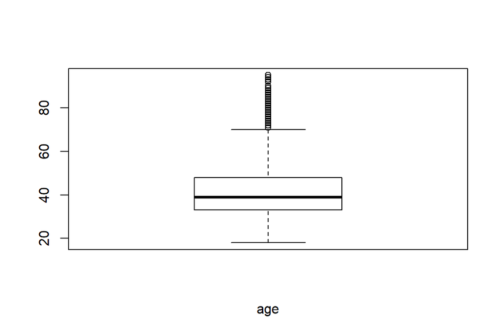

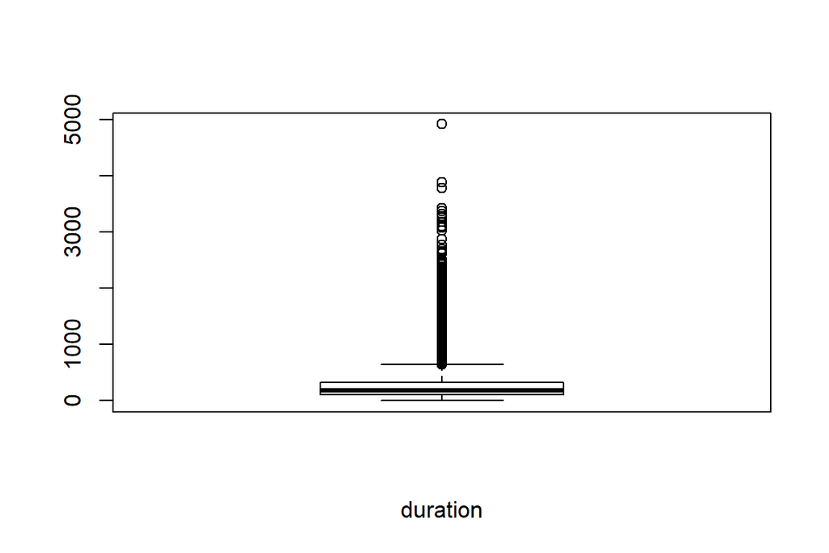

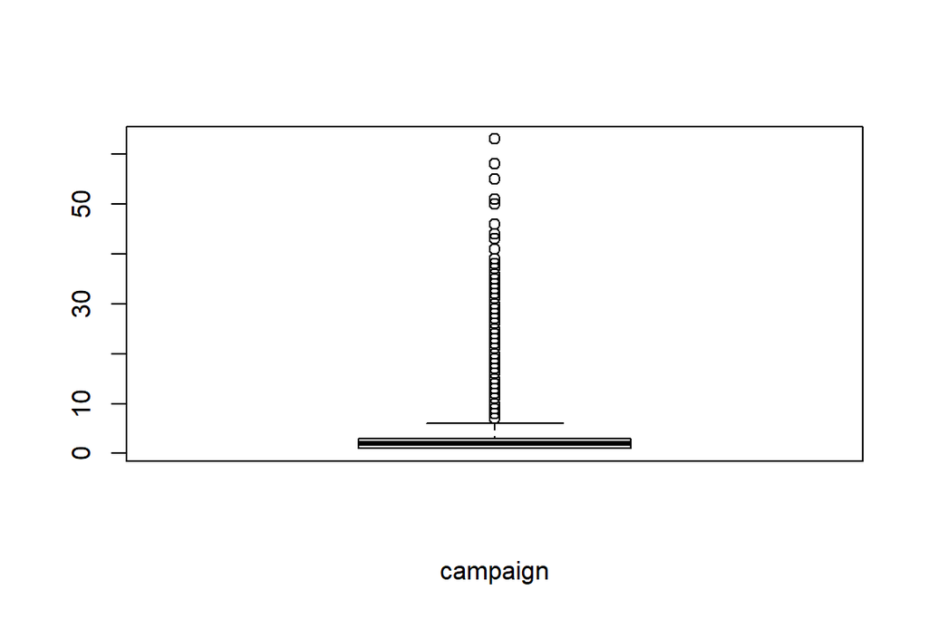

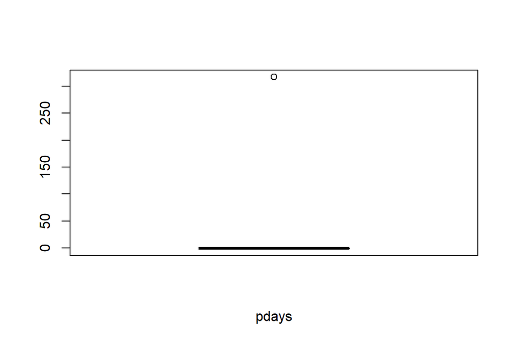

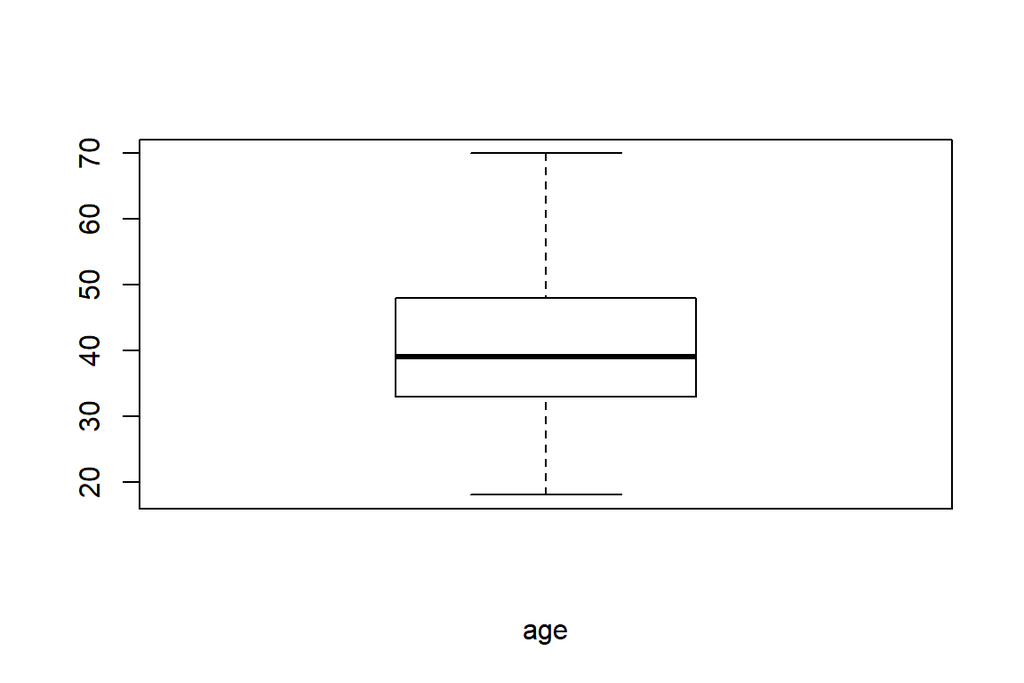

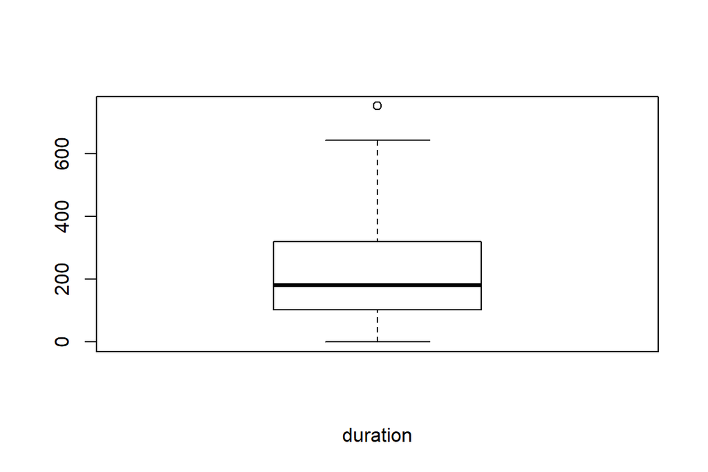

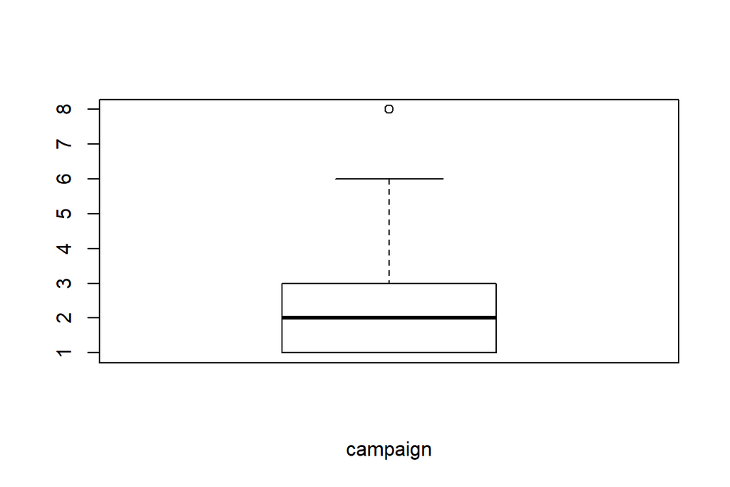

```r
# Clipping the outliers
for (i in col_outliers_to_remove){
  qnt <- quantile(bank_dataset[[i]], probs=c(.25, .75))
  caps <- quantile(bank_dataset[[i]], probs=c(.05, .95))
  H <- 1.5 * IQR(bank_dataset[[i]])
  bank_dataset[[i]][bank_dataset[[i]] < (qnt[1] - H)] <- caps[1]
  bank_dataset[[i]][bank_dataset[[i]] > (qnt[2] + H)] <- caps[2]
}

# Plot again the box plots to verify if the procedure has been successful
for (i in col_outliers_to_remove){
  boxplot(bank_dataset[,i], type="p", xlab=i)
}
```

#### Scaling

```r
# Feature scaling
numericFeatures = sapply(bank_dataset[,-1], is.numeric)
numericFeatures = c(FALSE, numericFeatures)
bank_dataset[numericFeatures] = sapply(bank_dataset[numericFeatures], scale)
```

#### Train and Test Split

```r
# Create dummy variables

bank_dataset$age <- NULL
bank_dataset$duration <- NULL
bank_dataset$campaign <- NULL
bank_dataset$balance <- NULL
bank_dataset <- dummy.data.frame(bank_dataset)
bank_dataset[["y"]] <- ifelse(bank_dataset$y0 == 1, 0,1)
bank_dataset$y <- as.factor(bank_dataset$y)
bank_dataset$y0 <- NULL
bank_dataset$y1 <- NULL
bank_dataset$yNA <- NULL

# Split the dataset into TRAIN and TEST
train_data <- as.data.frame(bank_dataset[bank_dataset$train_testtrain == 1,])
test_data <- as.data.frame(bank_dataset[bank_dataset$train_testtest == 1,])

train_data$train_testtrain <- NULL
train_data$train_testtest <- NULL
test_data$train_testtrain <- NULL
test_data$train_testtest <- NULL


dim(train_data)
```

```
## [1] 36168    97
```

```r
dim(test_data)
```

```
## [1] 9043   97
```

#### 15.1 Train / Validation split

We are going to split the annotated dataset in training and validation for the later evaluation of our regression models

```r
# Function to split a dataset into training and validation.
splitdf <- function(dataframe, seed=NULL) {
  if (!is.null(seed)) set.seed(seed)
    index <- 1:nrow(dataframe)
    trainindex <- sample(index, trunc(length(index)/1.2))
    trainset <- dataframe[trainindex, ]
    testset <- dataframe[-trainindex, ]
    list(trainset=trainset,testset=testset)
}

# Applying the function to the training_data
splits <- splitdf(train_data, seed = 8)

# Splitting the data into train set and validation set
training <- splits$trainset
validation <- splits$testset

# Append and split again to keep same factor levels
appended <- rbind(training, validation)
training <- appended[1:nrow(training),]
validation <- appended[nrow(training):nrow(appended),]
dim(training)
```

```
## [1] 30140    97
```

```r
dim(validation)
```

```
## [1] 6029   97
```

### Evaluation Function

```r
model_comparison <- data.frame()
eval_metrics <- function(name, real, predicted){
  model_comparison <- rbind(model_comparison, data.frame(model = name, accuracy = Accuracy(y_true = real, y_pred = predicted), precision = Precision(y_true = real, y_pred = predicted, positive = "1"), sensitivity =  Sensitivity(y_true = real, y_pred = predicted, positive = "1"), specificity = Specificity(y_true = real, y_pred = predicted, positive = "1"), recall = Recall(y_true = real, y_pred = predicted, positive = "1"), F1_score = F1_Score(y_true = real, y_pred = predicted, positive = "1"), AUC = AUC(y_true = real, y_pred = predicted)))
  return(model_comparison)

}
```

##### Train control

```r
trControl<- trainControl(method="repeatedcv",
                             number=5,
                             search="grid",
                             savePredictions = TRUE,
                             verboseIter = FALSE)
```

### XG BOOST

Let’s build a XG Boost model using differnet grid parameters and training control parameters, mentioned previously.

```r
xgbgrid <- expand.grid(
   nrounds=c(100, 200),
   max_depth = c(6, 10),
   eta = 0.05,
   gamma = c(0, 0.3),
   colsample_bytree = c(0.5, 0.75),
   subsample = 0.5,
   min_child_weight = c(1, 2, 5))

# train the xgboost learner
cv_xgboost <- caret::train(factor(y)~., data=data.matrix(training),
                           method = 'xgbTree',
                           metric = 'Accuracy',
                           trControl = trControl,
                           tuneGrid = xgbgrid)


# Best tunning parameters obtained
cv_xgboost$results
```

```
##     eta max_depth gamma colsample_bytree min_child_weight subsample
## 1  0.05         6   0.0             0.50                1       0.5
## 3  0.05         6   0.0             0.50                2       0.5
## 5  0.05         6   0.0             0.50                5       0.5
## 7  0.05         6   0.0             0.75                1       0.5
## 9  0.05         6   0.0             0.75                2       0.5
## 11 0.05         6   0.0             0.75                5       0.5
## 13 0.05         6   0.3             0.50                1       0.5
## 15 0.05         6   0.3             0.50                2       0.5
## 17 0.05         6   0.3             0.50                5       0.5
## 19 0.05         6   0.3             0.75                1       0.5
## 21 0.05         6   0.3             0.75                2       0.5
## 23 0.05         6   0.3             0.75                5       0.5
## 25 0.05        10   0.0             0.50                1       0.5
## 27 0.05        10   0.0             0.50                2       0.5
```

[output cut: 83 more lines]

```r
cv_xgboost$bestTune
```

```
##   nrounds max_depth  eta gamma colsample_bytree min_child_weight subsample
## 2     200         6 0.05     0              0.5                1       0.5
```

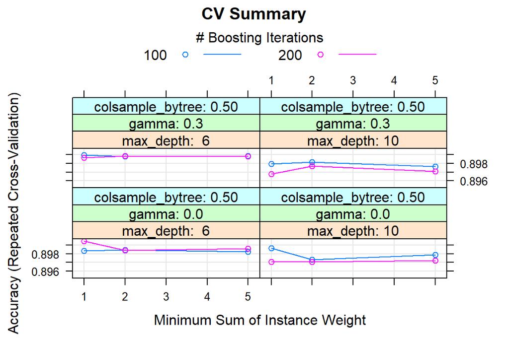

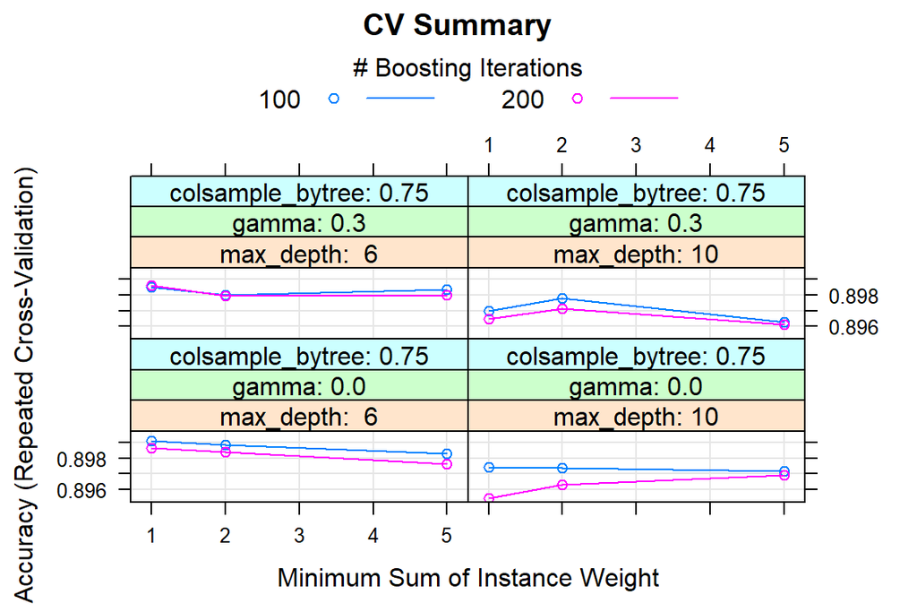

```r
# Let's check the variable importance
plot(cv_xgboost, main = "CV Summary")
```

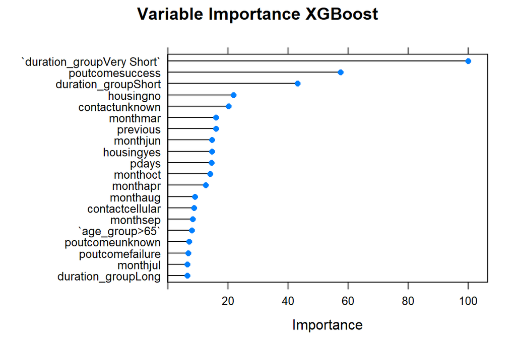

```r
# Top 20 important variable
plot(varImp(cv_xgboost), main = "Variable Importance XGBoost", top = 20)
```

```r
predictions_xgb <- predict(cv_xgboost, newdata = data.matrix(validation))

# Correcting levels 1 and 2 to 0 and 1
predictions_xgb <- ifelse(predictions_xgb == 1,0,1)

model_comparison <- eval_metrics("XGBoost", validation$y, predictions_xgb)
model_comparison
```

```
##     model  accuracy precision sensitivity specificity    recall F1_score
## 1 XGBoost 0.8955051 0.6267806   0.3059805   0.9753296 0.3059805 0.411215
##        AUC
## 1 0.640655
```

```r
cv_knn <- caret::train(as.factor(y)~., data=data.matrix(training),
                       method = "knn",
                       trControl = trControl,
                       preProcess = c("center","scale"),
                       tuneLength = 20,
                       tuneGrid= expand.grid(.k=c(5,8,10)))

# Best tunning parameters
cv_knn$bestTune
```

```
##   k
## 2 8
```

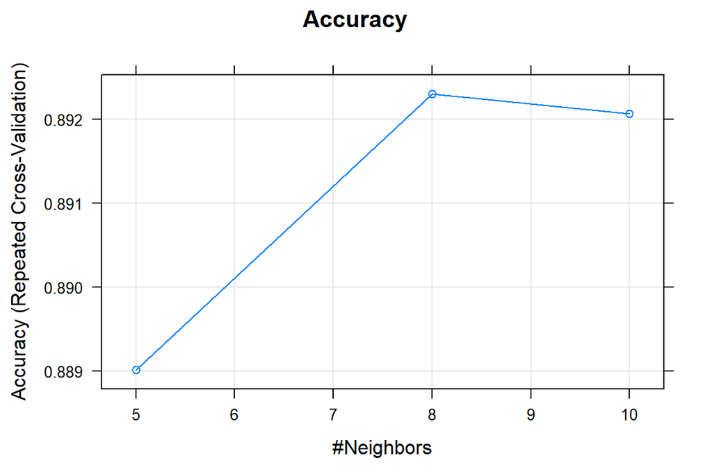

```r
# K vs Accuracy
plot(cv_knn, main = "Accuracy")
```

```r
# model performance

predictions_knn <- predict(cv_knn, newdata = data.matrix(validation))
predictions_knn <- ifelse(predictions_knn == 1,0,1)
model_comparison <- eval_metrics("KNN", validation$y, predictions_knn)
model_comparison
```

```
##     model  accuracy precision sensitivity specificity    recall  F1_score
## 1 XGBoost 0.8955051 0.6267806   0.3059805   0.9753296 0.3059805 0.4112150
## 2     KNN 0.8873777 0.5680272   0.2322670   0.9760829 0.2322670 0.3297137
##        AUC
## 1 0.640655
## 2 0.604175
```

##### Logistic Regression

```r
log_reg <- caret::train(as.formula(factor(y)~.), data = training,
                               method = "glm",
                               trControl = trControl,
                               tuneLength = 1,
                               metric = "Accuracy",
preProc = c("center", "scale"))

predictions_glm <- predict(log_reg, newdata = data.matrix(validation))

model_comparison <- eval_metrics("Logistic Regression", validation$y, predictions_glm)
model_comparison
```

```
##                 model  accuracy precision sensitivity specificity
## 1             XGBoost 0.8955051 0.6267806   0.3059805   0.9753296
## 2                 KNN 0.8873777 0.5680272   0.2322670   0.9760829
## 3 Logistic Regression 0.8940123 0.6197605   0.2878999   0.9760829
##      recall  F1_score       AUC
## 1 0.3059805 0.4112150 0.6406550
## 2 0.2322670 0.3297137 0.6041750
## 3 0.2878999 0.3931624 0.6319914
```

##### Random Forest

```r
tgrid <- expand.grid(
  .mtry = 2:4,
  .splitrule = "gini",
  .min.node.size = c(10, 20)
)

rf <- caret::train(as.factor(y)~., data = training,
                   method = "ranger",
                   metric = "Accuracy",
                   trControl = trControl,
                   preProc = c("center", "scale"),
                   tuneGrid = tgrid)

predictions_rf <- predict(rf, newdata = data.matrix(validation))

model_comparison <- eval_metrics("Random Forest", validation$y, predictions_rf)
model_comparison
```

```
##                 model  accuracy precision sensitivity specificity
## 1             XGBoost 0.8955051 0.6267806   0.3059805   0.9753296
## 2                 KNN 0.8873777 0.5680272   0.2322670   0.9760829
## 3 Logistic Regression 0.8940123 0.6197605   0.2878999   0.9760829
## 4       Random Forest 0.8931829 0.7245509   0.1682893   0.9913371
##      recall  F1_score       AUC
## 1 0.3059805 0.4112150 0.6406550
## 2 0.2322670 0.3297137 0.6041750
## 3 0.2878999 0.3931624 0.6319914
## 4 0.1682893 0.2731377 0.5798132
```

##### Support Vector Machine

```r
linearsvm <- caret::train(as.factor(y)~., data = training,
                   method = "svmLinear",
                   metric = "Accuracy",
                   trControl = trControl,
                   preProc = c("center", "scale"),
                   tuneGrid= data.frame(.C=10^(-4:-2)))

predictions_svmLinear <- predict(linearsvm, newdata = data.matrix(validation))

model_comparison <- eval_metrics("Linear SVM", validation$y, predictions_svmLinear)
model_comparison
```

```
##                 model  accuracy precision sensitivity specificity
## 1             XGBoost 0.8955051 0.6267806   0.3059805   0.9753296
## 2                 KNN 0.8873777 0.5680272   0.2322670   0.9760829
## 3 Logistic Regression 0.8940123 0.6197605   0.2878999   0.9760829
## 4       Random Forest 0.8931829 0.7245509   0.1682893   0.9913371
## 5          Linear SVM 0.8896998 0.6205357   0.1933241   0.9839925
##      recall  F1_score       AUC
## 1 0.3059805 0.4112150 0.6406550
## 2 0.2322670 0.3297137 0.6041750
## 3 0.2878999 0.3931624 0.6319914
## 4 0.1682893 0.2731377 0.5798132
## 5 0.1933241 0.2948038 0.5886583
```

```r
# tgrid <- expand.grid(sigma = c(.01, .015, 0.2),
#                     C = c(0.75, 0.9, 1, 1.1, 1.25))
#
# radialsvm <- caret::train(as.factor(y)~., data = training,
#                    method = "svmRadial",
#                    metric = "Accuracy",
#                    trControl = trControl,
#                    preProc = c("center", "scale"),
#                    tuneGrid = tgrid)
#
# predictions_svmRadial <- predict(radialsvm, newdata = data.matrix(validation))
#
# model_comparison <- eval_metrics("Non Linear SVM", validation$y, predictions_svmRadial)
# model_comparison
```

##### Resampling

Unbalanced classification problems cause problems to many learning algorithms. These problems are characterized by the uneven proportion of cases that are available for each class of the problem.

SMOTE (Chawla et. al. 2002) is a well-known algorithm to fight this problem. The general idea of this method is to artificially generate new examples of the minority class using the nearest neighbors of these cases. Furthermore, the majority class examples are also under-sampled, leading to a more balanced dataset.

```r
# killing old model comparison
model_comparison <- data.frame()

train_data_smoted <- SMOTE(y~., data=train_data, perc.over = 100, perc.under = 200, k=5)

# Applying the function to the training_data
splits <- splitdf(train_data_smoted, seed = 8)

# Splitting the data into train set and validation set
training_smoted <- splits$trainset
validation_smoted <- splits$testset

# Append and split again to keep same factor levels
appended <- rbind(training_smoted, validation_smoted)
training_smoted <- appended[1:nrow(training_smoted),]
validation_smoted <- appended[nrow(training_smoted):nrow(appended),]

table(train_data_smoted$y)
```

```
##
##    0    1
## 8390 8390
```